# Predicting Bike Share Trips in Philadelphia, PA

Roshini Ganesh

2023-12-18

## 1. Introduction

Bike sharing programs have expanded and revolutionized urban mobility worldwide. These initiatives, designed to provide convenient and sustainable mobility, allow users to rent bicycles for short-term use, providing a flexible alternative to traditional transit. In the city of Philadelphia, the Indego bike share system has emerged as a trailblazer in this movement. Launched in 2015, Indego has become an integral part of the city’s transportation fabric, offering residents and visitors a sustainable and convenient way of navigating the city.

The success of any bike share system hinges on maintaining a balanced distribution of bikes across its network of stations. Referred to as re-balancing, this process ensures that bikes are available where they are needed most, preventing shortages or surpluses at specific locations. Indego must address this challenge through strategic planning and innovative approaches, such as deploying dedicated fleets of trucks or incentivizing riders to assist in redistributing bikes.

The forecasting of bike demand plays a pivotal role in these re-balancing efforts. By predicting usage patterns over a specific time horizon, typically two weeks, Indego can proactively plan and implement re-balancing strategies, contributing to the seamless functioning of the bike share system to proactively meet the evolving needs of its diverse and active user base. Understanding these spatial and temporal trends will also allow Indego to make strategic decisions on how to allocate their resources and where to advertise their services. In this context, this study seeks to evaluate a rebalancing strategy for Indego based on their open trip data from the first quarter of 2023.

### 1.1 R Setup and Installing Packages

## 2. Data Overview

```r
# Read Indego Data from 2023 Quarter 2 - April to June

dat <- read.csv("indego-trips-2023-q1.csv")

# Create Time Bins for Indego Data

library(dplyr)
library(lubridate)

dat2 <- dat %>%
  mutate(interval60 = floor_date(mdy_hm(start_time), unit = "hour"),
         interval15 = floor_date(mdy_hm(start_time), unit = "15 mins"),
         week = week(interval60),
         dotw = wday(interval60, label=TRUE))

# Add Demographic Factors through ACS variables

library(tidycensus)

phillyCensus <-
  get_acs(geography = "tract",
          variables = c("B01003_001", "B19013_001",
                        "B02001_002", "B08013_001",
                        "B08012_001", "B08301_001",
                        "B08301_010", "B01002_001"),
          year = 2021,
          state = "PA",
          geometry = TRUE,
          county=c("Philadelphia"),
          output = "wide") %>%
  rename(Total_Pop =  B01003_001E, # reassign names for clarity
         Med_Inc = B19013_001E,
         Med_Age = B01002_001E,
         White_Pop = B02001_002E,
         Travel_Time = B08013_001E,
         Num_Commuters = B08012_001E,
         Means_of_Transport = B08301_001E,
         Total_Public_Trans = B08301_010E) %>%
  dplyr::select(Total_Pop, Med_Inc, White_Pop, Travel_Time,
         Means_of_Transport, Total_Public_Trans,
         Med_Age, GEOID, geometry) %>%
  mutate(Percent_White = White_Pop / Total_Pop, # calculate percentage of white population
         Mean_Commute_Time = Travel_Time / Total_Public_Trans,  # calculate mean commute time
         Percent_Taking_Public_Trans = Total_Public_Trans / Means_of_Transport)  # calculate percentage taking public transit

# Extract geometeries for Philadelphia

library(sf)

phillyTracts <-
  phillyCensus %>%
  as.data.frame() %>%
  distinct(GEOID, .keep_all = TRUE) %>%
  dplyr::select(GEOID, geometry) %>%
  st_sf%>%
  st_transform('EPSG:2263')

# Join spatial, demographic and Indego trip data

dat_census <- st_join(dat2 %>%
          filter(is.na(start_lon) == FALSE &
                   is.na(start_lat) == FALSE &
                   is.na(end_lon) == FALSE &
                   is.na(end_lat) == FALSE) %>%
          st_as_sf(., coords = c("start_lon", "start_lat"), crs = 4326),
        phillyTracts %>%
          st_transform(crs=4326),
        join=st_intersects,
              left = TRUE) %>%
  rename(Origin.Tract = GEOID) %>%
  mutate(start_lon = unlist(map(geometry, 1)),
         start_lat = unlist(map(geometry, 2)))%>%
  as.data.frame() %>%
  dplyr::select(-geometry)%>%
  st_as_sf(., coords = c("end_lon", "end_lat"), crs = 4326) %>%
  st_join(., phillyTracts %>%
            st_transform(crs=4326),
          join=st_intersects,
          left = TRUE) %>%
  rename(Destination.Tract = GEOID)  %>%
  mutate(end_lon = unlist(map(geometry, 1)),
         end_lat = unlist(map(geometry, 2)))%>%
  as.data.frame() %>%
  dplyr::select(-geometry)

# Add Weather Data for Philadelphia - April to June 2023

weather.Panel <-
  riem_measures(station = "PHL", date_start = "2023-01-01", date_end = "2023-03-31") %>%
  dplyr::select(valid, tmpf, p01i, sknt)%>%
  replace(is.na(.), 0) %>%
    mutate(date = as.Date(substr(valid,1,13)),
           week = week(date),
           dotw = wday(date),
           interval60 = ymd_h(substr(valid,1,13)))%>%
    group_by(interval60) %>%
    summarize(Temperature = max(tmpf),
              Precipitation = sum(p01i),
              Wind_Speed = max(sknt)) %>%
    mutate(Temperature = ifelse(Temperature == 0, 42, Temperature))
```

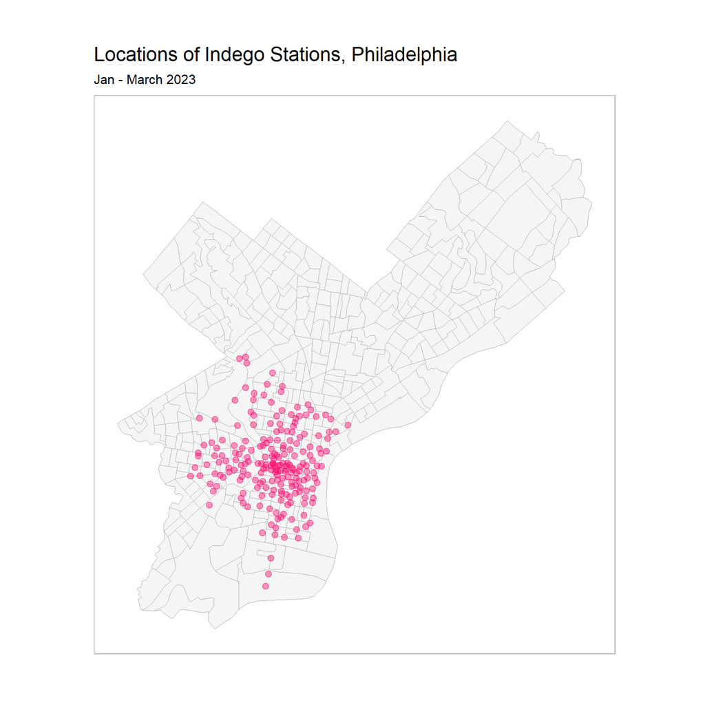

```r
# Plot locations of Indego stations in Philadelphia

stationdat <- dat %>%
  filter(!is.na(start_lon),
         !is.na(start_lat),
         !is.na(end_lon),
         !is.na(end_lat)) %>%
  st_as_sf(coords = c('start_lon', 'start_lat'), crs = 4326) %>%
  st_transform(crs = 4326) %>%
                mutate(date = as.Date(strptime(start_time, "%m/%d/%Y %H:%M")),
                       week = week(date),
                       dotw = wday(date),
                       interval60 = as.POSIXct(start_time, format = "%m/%d/%Y %H"))

ggplot() +
  geom_sf(data = phillyTracts, alpha=0.4, color="darkgrey") +
  geom_sf(data = stationdat %>%
            group_by(start_station) %>%
            summarize(count = n()),
          color = "#FF006A",
          alpha = 0.4) +
  labs(title = "Locations of Indego Stations, Philadelphia",
       subtitle = "Jan - March 2023")+
  mapTheme
```

## 3. Exploratory Analysis

### 3.1 Visualizing Ridership Over Time

On initial analysis, clear temporal trends emerge, revealing peak usage during specific hours of the day and an overarching increase in trip numbers over the course of the quarter. More number of trips are taken in March(early spring) than in January(winter), illustrating a clear seasonal-temporal-weather dependence trend.

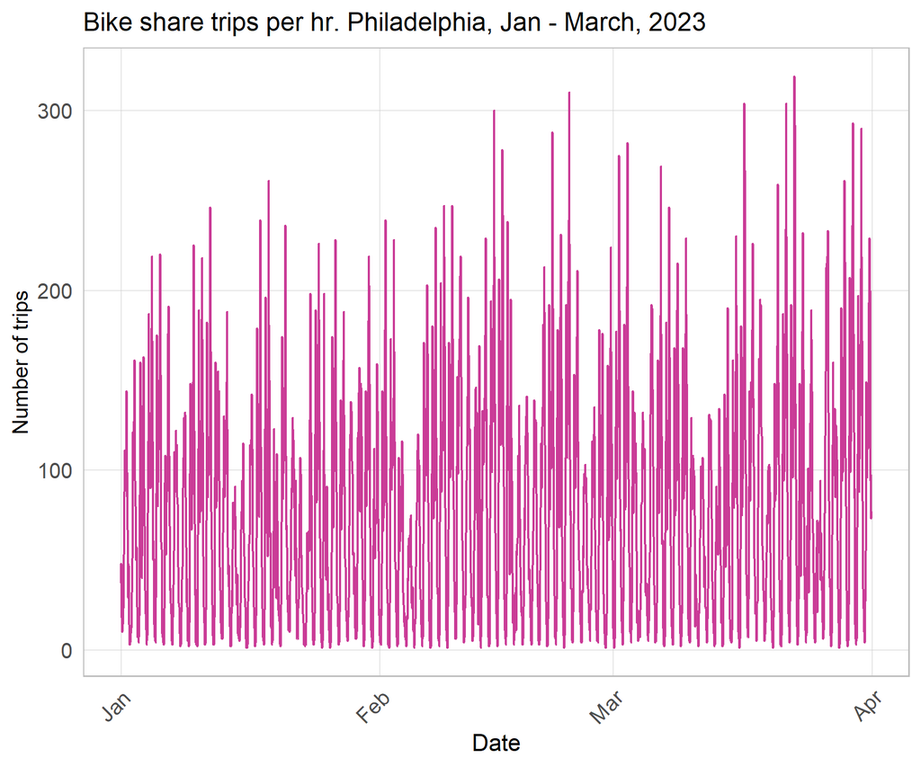

```r
# Trip timeseries

ggplot(dat_census %>%
         group_by(interval60) %>%
         tally())+
  geom_line(aes(x = interval60, y = n), colour="#CA3C97")+
  labs(title="Bike share trips per hr. Philadelphia, Jan - March, 2023",
       x="Date",
       y="Number of trips")+
  plotTheme
```

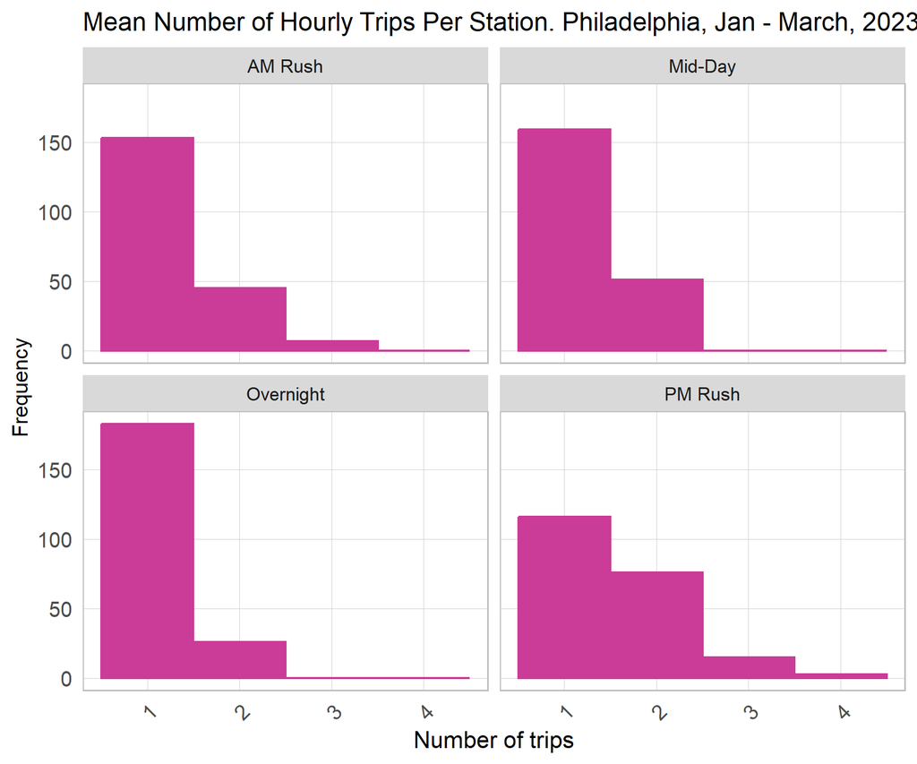

```r
# Mean Trips by hour by station

dat_census %>%
        mutate(time_of_day = case_when(hour(interval60) < 7 | hour(interval60) > 18 ~ "Overnight",
                                 hour(interval60) >= 7 & hour(interval60) < 10 ~ "AM Rush",
                                 hour(interval60) >= 10 & hour(interval60) < 15 ~ "Mid-Day",
                                 hour(interval60) >= 15 & hour(interval60) <= 18 ~ "PM Rush"))%>%
         group_by(interval60, start_station, time_of_day) %>%
         tally()%>%
  group_by(start_station, time_of_day)%>%
  summarize(mean_trips = mean(n))%>%
  ggplot()+
  geom_histogram(aes(mean_trips), binwidth = 1, colour="#CA3C97", fill="#CA3C97")+
  labs(title="Mean Number of Hourly Trips Per Station. Philadelphia, Jan - March, 2023",
       x="Number of trips",
       y="Frequency")+
  facet_wrap(~time_of_day)+
  plotTheme
```

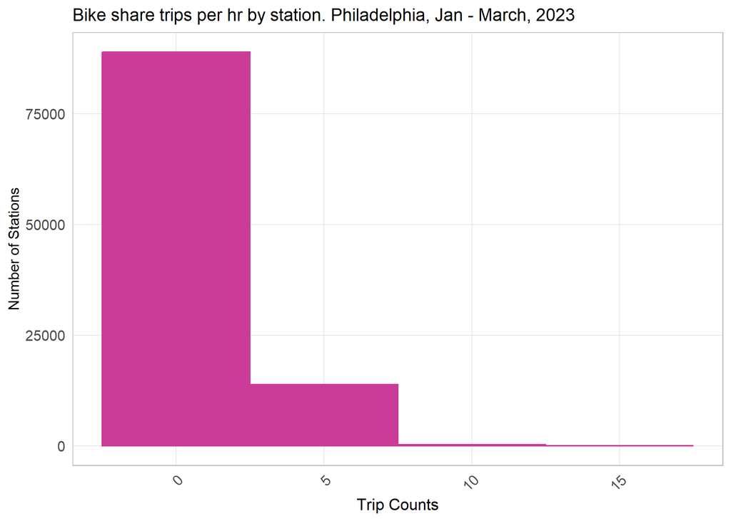

```r
# Station trip trends by hr

ggplot(dat_census %>%
         group_by(interval60, start_station) %>%
         tally())+
  geom_histogram(aes(n), binwidth = 5, colour="#CA3C97", fill="#CA3C97")+
  labs(title="Bike share trips per hr by station. Philadelphia, Jan - March, 2023",
       x="Trip Counts",
       y="Number of Stations")+
  plotTheme
```

The next two figures are particularly interesting because they potentially point to the difference in rider demographics. The hypothesis is that Indego, at present, caters to two main user groups. Firstly, there are commuters who contribute to the pronounced peaks during weekday AM and PM rush hours. Secondly, there are tourists/ city-explorers who appear to drive the peak in mid-day hours during weekends. This hypothesis implies that the bike share usage patterns may be influenced by distinct user groups with different preferences and schedules.

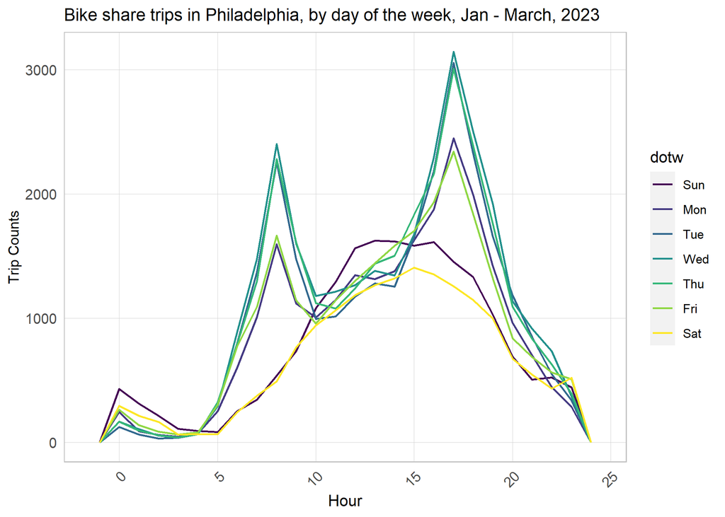

```r
# Weekday vs Weekend Trends

ggplot(dat_census %>% mutate(hour = hour(interval60)))+
     geom_freqpoly(aes(hour, color = dotw), binwidth = 1, size=.7)+
  labs(title="Bike share trips in Philadelphia, by day of the week, Jan - March, 2023",
       x="Hour",
       y="Trip Counts")+
     plotTheme
```

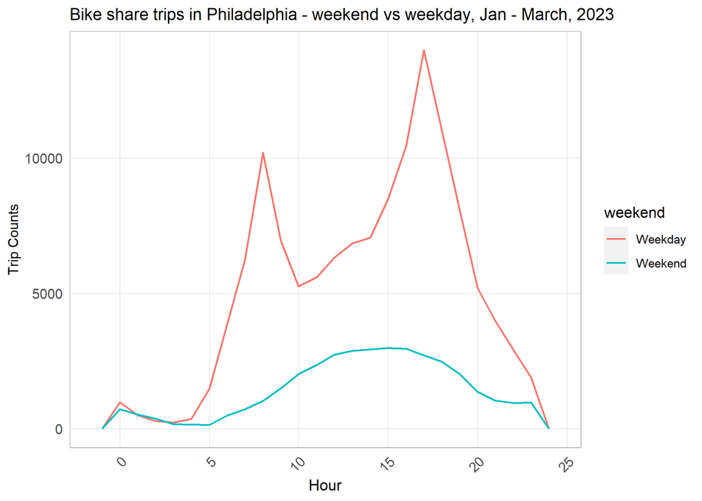

```r
ggplot(dat_census %>%
         mutate(hour = hour(interval60),
                weekend = ifelse(dotw %in% c("Sun", "Sat"), "Weekend", "Weekday")))+
     geom_freqpoly(aes(hour, color = weekend), binwidth = 1, size=.7)+
  labs(title="Bike share trips in Philadelphia - weekend vs weekday, Jan - March, 2023",
       x="Hour",
       y="Trip Counts")+
     plotTheme
```

Additionally, mapping the data suggests that a majority of trips are taken out of Center City. This spatial clustering might be because of a variety of factors including more Indego stations, higher access to bikes, proximity to SEPTA Stops, the density of the area, and the footfall that Center City receives everyday. Below are a series of time-use maps illustrating the distribution of trip origins across the city.

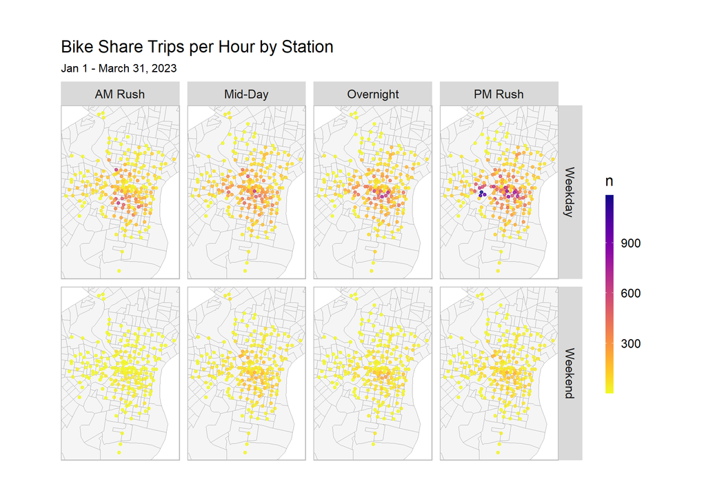

```r
# Trips by Origin Station

indego_points <-
  dat_census %>%
  mutate(hour = hour(mdy_hm(start_time)),
         weekend = ifelse(dotw %in% c("Sun", "Sat"), "Weekend", "Weekday"),
         time_of_day = case_when(hour(interval60) < 7 | hour(interval60) > 18 ~ "Overnight",
                                 hour(interval60) >= 7 & hour(interval60) < 10 ~ "AM Rush",
                                 hour(interval60) >= 10 & hour(interval60) < 15 ~ "Mid-Day",
                                 hour(interval60) >= 15 & hour(interval60) <= 18 ~ "PM Rush"))%>%
  group_by(start_station, start_lat, start_lon, weekend, time_of_day)

ggplot()+
  geom_sf(data = phillyTracts %>%
            st_transform(crs=4326), alpha = 0.4, color="darkgrey")+
  geom_point(data = indego_points %>%
             tally(),
             aes(x=start_lon, y = start_lat, color = n),
             fill = "transparent", alpha = 0.8, size = 0.8)+
  scale_colour_viridis(direction = -1,
                       discrete = FALSE, option = "C")+
  ylim(min(indego_points$start_lat), max(indego_points$start_lat))+
  xlim(min(indego_points$start_lon), max(indego_points$start_lon))+
  facet_grid(weekend ~ time_of_day)+
  labs(title="Bike Share Trips per Hour by Station",
       subtitle= "Jan 1 - March 31, 2023")+
  mapTheme
```

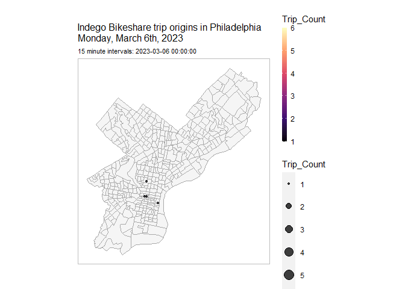

```r
# Animated Map - Spatio Temporal Distribution of Ridership

stations<-
  dat2 %>%
  dplyr::select(start_station, start_lon, start_lat) %>%
  group_by(start_station) %>%
  distinct()%>%
  filter(is.na(start_lon) == FALSE &
           is.na(start_lat) == FALSE) %>%
  st_as_sf(., coords = c("start_lon", "start_lat"), crs = 4326)

rides.animation.df <- dat_census %>%
  filter(week == 10 & dotw == "Mon") %>%
  mutate(Trip_Counter = 1) %>%
  group_by(interval15, start_station) %>%
  summarize(Trip_Count = sum(Trip_Counter, na.rm=T)) %>%
  left_join(., stations, by =c("start_station" = "start_station")) %>%
  st_sf() %>%
  ungroup() %>%
  mutate(Trips = case_when(Trip_Count == 0 ~ "0 trips",
          Trip_Count > 0 & Trip_Count <= 3 ~ "1-3 trips",
          Trip_Count > 3 & Trip_Count <= 6 ~ "4-6 trips",
          Trip_Count > 6 & Trip_Count <= 10 ~ "7-10 trips",
          Trip_Count > 10 ~ "11+ trips")) %>%
  mutate(Trips  = fct_relevel(Trips, "0 trips","1-3 trips","4-6 trips",
  "7-10 trips","10+ trips")) %>%
  arrange(Trips)

ride_animation <-
  ggplot()+
  geom_sf(data = phillyTracts, alpha = 0.4, color="darkgrey") +
  geom_point(data = rides.animation.df,
          aes(color=Trip_Count, size = Trip_Count, geometry = geometry),
          stat = "sf_coordinates",
          fill = "transparent", alpha = 0.75)+
  scale_colour_viridis_c(direction = 1, option = "magma")+
  # ylim(min(rides$start_lat), max(rides$start_lat))+
  # xlim(min(rides$start_lng), max(rides$start_lng))+
  labs(title="Indego Bikeshare trip origins in Philadelphia\nMonday, March 6th, 2023",
       subtitle = "15 minute intervals: {current_frame}") +
  mapTheme +
  transition_manual(interval15)

animate(ride_animation, duration=20, renderer = gifski_renderer())
```

The following trip count sum map by week for each station by week also supports the observation about the presence of spatial clustering in bikeshare usage.

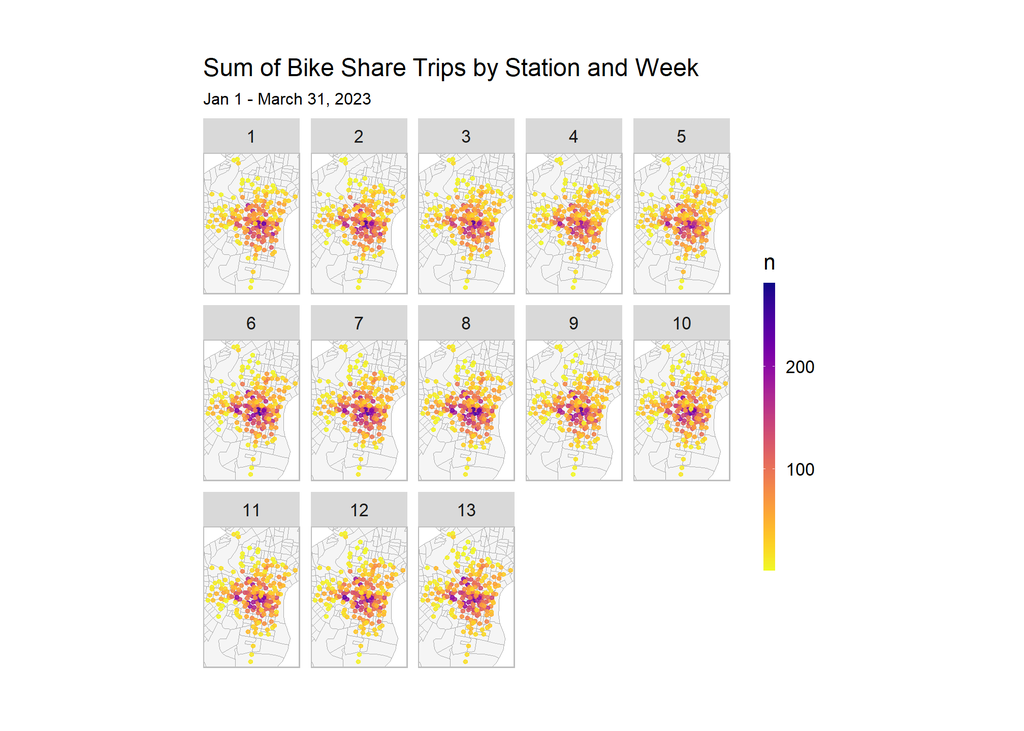

```r
# Sum of Trips by Week

ggplot()+
  geom_sf(data = phillyCensus, alpha=0.4, color="darkgrey")+
  geom_point(data = dat_census %>%
               group_by(start_station, start_lat, start_lon, week)%>%
               tally(),
             aes(x=start_lon, y = start_lat, color = n),
             fill = "transparent", alpha = 0.85, size = .7)+
  scale_colour_viridis(direction = -1,
                       discrete = FALSE, option = "C")+
  ylim(min(dat_census$start_lat), max(dat_census$start_lat))+
  xlim(min(dat_census$start_lon), max(dat_census$start_lon))+
  facet_wrap(~week, nrow = 3)+
  labs(title="Sum of Bike Share Trips by Station and Week",
       subtitle = "Jan 1 - March 31, 2023")+
  mapTheme
```

### 3.2 Feature Engineering

In constructing the model, various predictors are integrated, including weather, spatial factors, and temporal lag. An important new variable created is ‘temporal lags’ which exhibits a strong correlation with the dependent variable, Trip_Count. This finding underscores the significance of incorporating time-related factors to enhance the predictive capabilities of the model.

```r
length(unique(dat_census$interval60)) * length(unique(dat_census$start_station))

# Study Panel

study.panel <-
  expand.grid(interval60=unique(dat_census$interval60),
              start_station = unique(dat_census$start_station)) %>%
  left_join(., dat_census %>%
              select(start_station, Origin.Tract, start_lon, start_lat)%>%
              distinct() %>%
              group_by(start_station) %>%
              slice(1))

nrow(study.panel)

# Ride Panel

ride.panel <-
  dat_census %>%
  mutate(Trip_Counter = 1) %>%
  right_join(study.panel) %>%
  group_by(interval60, start_station, Origin.Tract, start_lon, start_lat) %>%
  summarize(Trip_Count = sum(Trip_Counter, na.rm=T)) %>%
  left_join(weather.Panel) %>%
  ungroup() %>%
  filter(is.na(start_station) == FALSE) %>%
  mutate(week = week(interval60),
         dotw = wday(interval60, label = TRUE)) %>%
  filter(is.na(Origin.Tract) == FALSE)

# Census and Panel

ride.panel <-
  left_join(ride.panel, phillyCensus %>%
              as.data.frame() %>%
              select(-geometry), by = c("Origin.Tract" = "GEOID"))%>%
              na.omit()
```

## 4. Regression

```r
# Time Lags

ride.panel <-
  ride.panel %>%
  arrange(start_station, interval60) %>%
  mutate(lagHour = dplyr::lag(Trip_Count,1),
         lag2Hours = dplyr::lag(Trip_Count,2),
         lag3Hours = dplyr::lag(Trip_Count,3),
         lag4Hours = dplyr::lag(Trip_Count,4),
         lag12Hours = dplyr::lag(Trip_Count,12),
         lag1day = dplyr::lag(Trip_Count,24),
         holiday = ifelse(yday(interval60) == 148,1,0)) %>%
   mutate(day = yday(interval60)) %>%
   mutate(holidayLag = case_when(dplyr::lag(holiday, 1) == 1 ~ "PlusOneDay",
                                 dplyr::lag(holiday, 2) == 1 ~ "PlustTwoDays",
                                 dplyr::lag(holiday, 3) == 1 ~ "PlustThreeDays",
                                 dplyr::lead(holiday, 1) == 1 ~ "MinusOneDay",
                                 dplyr::lead(holiday, 2) == 1 ~ "MinusTwoDays",
                                 dplyr::lead(holiday, 3) == 1 ~ "MinusThreeDays"),
         holidayLag = ifelse(is.na(holidayLag) == TRUE, 0, holidayLag))

# Evaluate Lags

as.data.frame(ride.panel) %>%
    group_by(interval60) %>%
    summarise_at(vars(starts_with("lag"), "Trip_Count"), mean, na.rm = TRUE) %>%
    gather(Variable, Value, -interval60, -Trip_Count) %>%
    mutate(Variable = factor(Variable, levels=c("lagHour","lag2Hours","lag3Hours","lag4Hours",
                                                "lag12Hours","lag1day")))%>%
    group_by(Variable) %>%
    summarize(correlation = round(cor(Value, Trip_Count),2))
```

```
## # A tibble: 6 × 2
##   Variable   correlation
##   <fct>            <dbl>
## 1 lagHour           0.86
## 2 lag2Hours         0.67
## 3 lag3Hours         0.45
## 4 lag4Hours         0.27
## 5 lag12Hours       -0.48
## 6 lag1day           0.79
```

An OLS regression is used for prediction for different combinations of time, space, weather, station and demographic data to identify the best model. The best performing model is then validated by the random-k-fold method.

Regression data:

- Regression 1- reg1 focuses on just time, including hour fixed effects, day of the week, and Temperature
- Regression 2- reg2 focuses on time and space effects
- Regression 3- reg3 focuses on time and space effects and adds lag features
- Regression 4- reg4 focuses on time, space, and demographic effects
- Regression 5- reg4 focuses on time, space, and demographic effects and adds lag features

```r
# Split Data
ride.Train <- filter(ride.panel, week >= 5 & week <=8)
ride.Test <- filter(ride.panel, week >=9 & week<= 10)
```

Regression 1:

```r
# Regression 1 - Temporal variables only

reg1 <-
  lm(Trip_Count ~  hour(interval60) + dotw + Temperature,  data=ride.Train)

summary(reg1)
```

```
##
## Call:
## lm(formula = Trip_Count ~ hour(interval60) + dotw + Temperature,
##     data = ride.Train)
##
## Residuals:
##     Min      1Q  Median      3Q     Max
## -0.8227 -0.4563 -0.2755  0.0006 12.3665
##
## Coefficients:
##                    Estimate Std. Error t value Pr(>|t|)
## (Intercept)      -0.3407475  0.0116017 -29.371  < 2e-16 ***
## hour(interval60)  0.0164034  0.0003340  49.105  < 2e-16 ***
## dotw.L            0.0370530  0.0062250   5.952 2.65e-09 ***
## dotw.Q           -0.0550937  0.0063929  -8.618  < 2e-16 ***
## dotw.C            0.0490303  0.0061662   7.951 1.86e-15 ***
## dotw^4            0.0559549  0.0061663   9.074  < 2e-16 ***
## dotw^5            0.0161485  0.0060827   2.655  0.00794 **
## dotw^6           -0.0016392  0.0060529  -0.271  0.78653
## Temperature       0.0123979  0.0002608  47.529  < 2e-16 ***
## ---
## Signif. codes:  0 '***' 0.001 '**' 0.01 '*' 0.05 '.' 0.1 ' ' 1
##
## Residual standard error: 0.8282 on 130836 degrees of freedom
## Multiple R-squared:  0.04462,    Adjusted R-squared:  0.04456
## F-statistic: 763.8 on 8 and 130836 DF,  p-value: < 2.2e-16
```

Regression 2:

```r
# Regression 2 - Spatio-Temporal variables

reg2 <-
  lm(Trip_Count ~  start_station + hour(interval60) + dotw + Temperature + Precipitation,
     data=ride.Train)

summary(reg2)
```

```
##
## Call:
## lm(formula = Trip_Count ~ start_station + hour(interval60) +
##     dotw + Temperature + Precipitation, data = ride.Train)
##
## Residuals:
##     Min      1Q  Median      3Q     Max
## -1.0377 -0.4475 -0.2564  0.1040 12.4217
##
## Coefficients:
##                    Estimate Std. Error t value Pr(>|t|)
## (Intercept)       3.880e+00  7.030e-02  55.198  < 2e-16 ***
## start_station    -1.338e-03  2.193e-05 -61.021  < 2e-16 ***
## hour(interval60)  1.622e-02  3.296e-04  49.197  < 2e-16 ***
## dotw.L            4.284e-02  6.155e-03   6.959 3.43e-12 ***
## dotw.Q           -5.305e-02  6.303e-03  -8.416  < 2e-16 ***
## dotw.C            4.397e-02  6.093e-03   7.216 5.37e-13 ***
## dotw^4            5.227e-02  6.086e-03   8.590  < 2e-16 ***
## dotw^5            1.105e-02  6.011e-03   1.838    0.066 .
## dotw^6           -2.273e-03  5.966e-03  -0.381    0.703
## Temperature       1.277e-02  2.591e-04  49.299  < 2e-16 ***
## Precipitation    -2.460e-01  2.108e-02 -11.673  < 2e-16 ***
## ---
## Signif. codes:  0 '***' 0.001 '**' 0.01 '*' 0.05 '.' 0.1 ' ' 1
##
## Residual standard error: 0.8162 on 130834 degrees of freedom
## Multiple R-squared:  0.072,  Adjusted R-squared:  0.07193
## F-statistic:  1015 on 10 and 130834 DF,  p-value: < 2.2e-16
```

Regression 3:

```r
# Regression 3 - Spatio-Temporal + Lag variables

reg3 <-
  lm(Trip_Count ~  start_station + hour(interval60) + dotw + Temperature + Precipitation +
                   lagHour + lag2Hours +lag3Hours +lag12Hours + lag1day,
     data=ride.Train)

summary(reg3)
```

```
##
## Call:
## lm(formula = Trip_Count ~ start_station + hour(interval60) +
##     dotw + Temperature + Precipitation + lagHour + lag2Hours +
##     lag3Hours + lag12Hours + lag1day, data = ride.Train)
##
## Residuals:
##     Min      1Q  Median      3Q     Max
## -3.9649 -0.3035 -0.1293  0.0110 11.4200
##
## Coefficients:
##                    Estimate Std. Error t value Pr(>|t|)
## (Intercept)       1.465e+00  6.627e-02  22.105  < 2e-16 ***
## start_station    -5.181e-04  2.068e-05 -25.052  < 2e-16 ***
## hour(interval60)  3.489e-03  3.134e-04  11.135  < 2e-16 ***
## dotw.L           -2.814e-03  5.577e-03  -0.505  0.61384
## dotw.Q           -1.829e-02  5.721e-03  -3.196  0.00139 **
## dotw.C            2.890e-02  5.513e-03   5.243 1.58e-07 ***
## dotw^4            3.047e-02  5.505e-03   5.536 3.11e-08 ***
## dotw^5            1.556e-02  5.439e-03   2.861  0.00422 **
## dotw^6           -5.905e-03  5.395e-03  -1.095  0.27372
## Temperature       6.585e-03  2.376e-04  27.717  < 2e-16 ***
## Precipitation    -2.219e-01  1.908e-02 -11.629  < 2e-16 ***
## lagHour           1.851e-01  2.742e-03  67.497  < 2e-16 ***
## lag2Hours         1.285e-01  2.749e-03  46.731  < 2e-16 ***
## lag3Hours         5.507e-02  2.699e-03  20.404  < 2e-16 ***
## lag12Hours       -2.031e-03  2.474e-03  -0.821  0.41158
## lag1day           2.455e-01  2.639e-03  93.036  < 2e-16 ***
## ---
## Signif. codes:  0 '***' 0.001 '**' 0.01 '*' 0.05 '.' 0.1 ' ' 1
##
## Residual standard error: 0.738 on 130829 degrees of freedom
## Multiple R-squared:  0.2413, Adjusted R-squared:  0.2412
## F-statistic:  2773 on 15 and 130829 DF,  p-value: < 2.2e-16
```

Regression 4:

```r
# Regression 4 - Spatio-Temporal + Demographic variables

reg4 <-
  lm(Trip_Count ~  start_station +  hour(interval60) + dotw + Temperature + Precipitation + Total_Pop +
       Percent_White + Mean_Commute_Time + Percent_Taking_Public_Trans + Med_Inc,
     data=ride.Train)

summary(reg4)
```

```
##
## Call:
## lm(formula = Trip_Count ~ start_station + hour(interval60) +
##     dotw + Temperature + Precipitation + Total_Pop + Percent_White +
##     Mean_Commute_Time + Percent_Taking_Public_Trans + Med_Inc,
##     data = ride.Train)
##
## Residuals:
##     Min      1Q  Median      3Q     Max
## -1.1756 -0.4580 -0.2359  0.1838 12.3823
##
## Coefficients:
##                               Estimate Std. Error t value Pr(>|t|)
## (Intercept)                  3.354e+00  7.430e-02  45.139  < 2e-16 ***
## start_station               -1.121e-03  2.225e-05 -50.384  < 2e-16 ***
## hour(interval60)             1.622e-02  3.258e-04  49.777  < 2e-16 ***
## dotw.L                       4.284e-02  6.083e-03   7.041 1.91e-12 ***
## dotw.Q                      -5.305e-02  6.230e-03  -8.516  < 2e-16 ***
## dotw.C                       4.397e-02  6.022e-03   7.301 2.87e-13 ***
## dotw^4                       5.227e-02  6.015e-03   8.691  < 2e-16 ***
## dotw^5                       1.105e-02  5.941e-03   1.860   0.0629 .
## dotw^6                      -2.273e-03  5.896e-03  -0.386   0.6999
## Temperature                  1.277e-02  2.561e-04  49.880  < 2e-16 ***
## Precipitation               -2.460e-01  2.083e-02 -11.810  < 2e-16 ***
## Total_Pop                   -3.511e-05  1.850e-06 -18.980  < 2e-16 ***
## Percent_White                4.053e-01  1.320e-02  30.692  < 2e-16 ***
## Mean_Commute_Time           -4.849e-04  6.267e-05  -7.736 1.03e-14 ***
## Percent_Taking_Public_Trans -6.322e-01  3.682e-02 -17.170  < 2e-16 ***
## Med_Inc                     -7.564e-07  8.085e-08  -9.356  < 2e-16 ***
## ---
## Signif. codes:  0 '***' 0.001 '**' 0.01 '*' 0.05 '.' 0.1 ' ' 1
##
## Residual standard error: 0.8067 on 130829 degrees of freedom
## Multiple R-squared:  0.09353,    Adjusted R-squared:  0.09343
## F-statistic:   900 on 15 and 130829 DF,  p-value: < 2.2e-16
```

Regression 5:

```r
# Regression 5 - Spatio-Temporal + Demographic + Lag variables

reg5 <-
  lm(Trip_Count ~  start_station + hour(interval60) + dotw + Temperature + Precipitation +
                   + Total_Pop + Percent_White + Mean_Commute_Time + Percent_Taking_Public_Trans + Med_Inc +
                   lagHour + lag2Hours + lag3Hours +lag12Hours + lag1day,
     data=ride.Train)

summary(reg5)
```

```
##
## Call:
## lm(formula = Trip_Count ~ start_station + hour(interval60) +
##     dotw + Temperature + Precipitation + +Total_Pop + Percent_White +
##     Mean_Commute_Time + Percent_Taking_Public_Trans + Med_Inc +
##     lagHour + lag2Hours + lag3Hours + lag12Hours + lag1day, data = ride.Train)
##
## Residuals:
##     Min      1Q  Median      3Q     Max
## -3.8690 -0.3097 -0.1314  0.0366 11.4236
##
## Coefficients:
##                               Estimate Std. Error t value Pr(>|t|)
## (Intercept)                  1.374e+00  6.992e-02  19.656  < 2e-16 ***
## start_station               -4.680e-04  2.094e-05 -22.354  < 2e-16 ***
## hour(interval60)             3.836e-03  3.130e-04  12.257  < 2e-16 ***
## dotw.L                      -1.499e-03  5.565e-03  -0.269 0.787597
## dotw.Q                      -2.115e-02  5.709e-03  -3.704 0.000212 ***
## dotw.C                       2.905e-02  5.500e-03   5.282 1.28e-07 ***
## dotw^4                       3.093e-02  5.492e-03   5.632 1.79e-08 ***
## dotw^5                       1.577e-02  5.426e-03   2.906 0.003665 **
## dotw^6                      -5.718e-03  5.383e-03  -1.062 0.288140
## Temperature                  6.745e-03  2.371e-04  28.445  < 2e-16 ***
## Precipitation               -2.232e-01  1.904e-02 -11.722  < 2e-16 ***
## Total_Pop                   -1.461e-05  1.696e-06  -8.615  < 2e-16 ***
## Percent_White                1.686e-01  1.219e-02  13.824  < 2e-16 ***
## Mean_Commute_Time           -2.054e-04  5.725e-05  -3.588 0.000333 ***
## Percent_Taking_Public_Trans -2.623e-01  3.374e-02  -7.773 7.69e-15 ***
## Med_Inc                     -3.163e-07  7.388e-08  -4.281 1.86e-05 ***
## lagHour                      1.803e-01  2.743e-03  65.716  < 2e-16 ***
## lag2Hours                    1.236e-01  2.750e-03  44.957  < 2e-16 ***
## lag3Hours                    4.960e-02  2.702e-03  18.352  < 2e-16 ***
## lag12Hours                  -1.056e-02  2.493e-03  -4.236 2.28e-05 ***
## lag1day                      2.394e-01  2.644e-03  90.544  < 2e-16 ***
## ---
## Signif. codes:  0 '***' 0.001 '**' 0.01 '*' 0.05 '.' 0.1 ' ' 1
##
## Residual standard error: 0.7364 on 130824 degrees of freedom
## Multiple R-squared:  0.2447, Adjusted R-squared:  0.2446
## F-statistic:  2119 on 20 and 130824 DF,  p-value: < 2.2e-16
```

Mean Absolute Error (MAE) is calculated on ride.Test for each model. To understand if models generalize to the holiday and non-holiday weeks, ride.Test.weekNest nests ride.Test by week. However, this is not relevant for this particular timeframe considered because there are no holidays and theredore no holiday effects.

```r
# Nest Data

ride.Test.weekNest <-
  ride.Test %>%
  nest(-week)
```

Next, a small function is created that takes a tibble, dat and a regression model, fit as its inputs, and outputs predictions as pred. This function is used to predict for each week in ride.Trest.weekNest.

```r
# Predict Function

model_pred <- function(dat, fit){
   pred <- predict(fit, newdata = dat)}
```

The nested format below loops through each model for each week to calculate week-wise predictions and errors.

```r
# Create Predictions

week_predictions <-
  ride.Test.weekNest %>%
    mutate(ATime_FE = map(.x = data, fit = reg1, .f = model_pred),
           BSpace_FE = map(.x = data, fit = reg2, .f = model_pred),
           CTime_Space_FE = map(.x = data, fit = reg3, .f = model_pred),
           DTime_Space_FE_timeLags = map(.x = data, fit = reg4, .f = model_pred),
           ETime_Space_FE_timeLags_holidayLags = map(.x = data, fit = reg5, .f = model_pred)) %>%
    gather(Regression, Prediction, -data, -week) %>%
    mutate(Observed = map(data, pull, Trip_Count),
           Absolute_Error = map2(Observed, Prediction,  ~ abs(.x - .y)),
           MAE = map_dbl(Absolute_Error, mean, na.rm = TRUE),
           sd_AE = map_dbl(Absolute_Error, sd, na.rm = TRUE))
```

### 4.1 Cross Validation

On cross validating the model using a 100 fold random k-fold method, it is seen that the MAE for the Time-Space-Demographic-Lags model is .44 which implies that the model may have an error in prediction for 1 trip at the most, which is acceptable.

```r
# Cross Validation

folds <- 100

library(caret)
control <- trainControl(method="cv", number=folds)


set.seed(123)

model_cv <- train(Trip_Count ~ start_station + hour(interval60) + dotw + Temperature + Precipitation +
                   lagHour + lag2Hours +lag3Hours +lag12Hours + lag1day + holidayLag + holiday +
                   Total_Pop + Percent_White + Med_Inc + Percent_Taking_Public_Trans,
                  data=na.omit(ride.panel),
                  method="lm",
                  trControl=control)

cv_df <- data.frame(
  model = "ETime_Space_FE_timeLags_holidayLags",
  folds = folds,
  rmse = model_cv$results$RMSE,
  mae = model_cv$results$MAE
)

cv_df %>%
    kbl(caption = "Cross-Validation Results")%>%
    kable_styling("striped", full_width = F)
```

Cross-Validation Results

| model | folds | rmse | mae |
| --- | --- | --- | --- |
| ETime_Space_FE_timeLags_holidayLags | 100 | 0.7171156 | 0.4382355 |

### 4.2 Errors in Prediction

On exploring the Mean Absolute Error Values for each model, it is found that the Time-Space-Lag model (reg3) has the least errors along with the Time-Space-Demographics-Lag model (reg5). In both cases, the model is differentiated by the incorporation of time lag features with spatial and demographic variables only being minor contributors of influence.

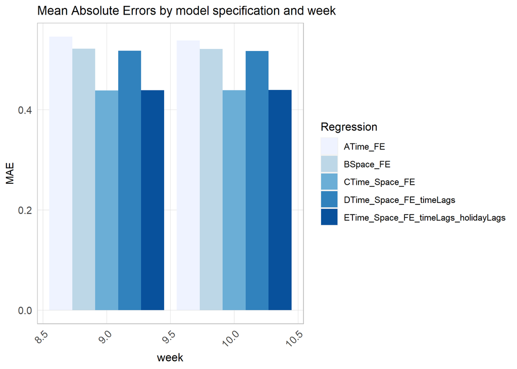

```r
# Plot Errors by model

week_predictions %>%
  dplyr::select(week, Regression, MAE) %>%
  gather(Variable, MAE, -Regression, -week) %>%
  ggplot(aes(week, MAE)) +
    geom_bar(aes(fill = Regression), position = "dodge", stat="identity") +
    scale_fill_manual(values = palette5) +
    labs(title = "Mean Absolute Errors by model specification and week") +
  plotTheme
```

The models, however, consistently underpredict trip counts. This is an area of concern because it would not allow Indego to allocate resources effectively and may result in under-serving or under-equipping stations in the city.

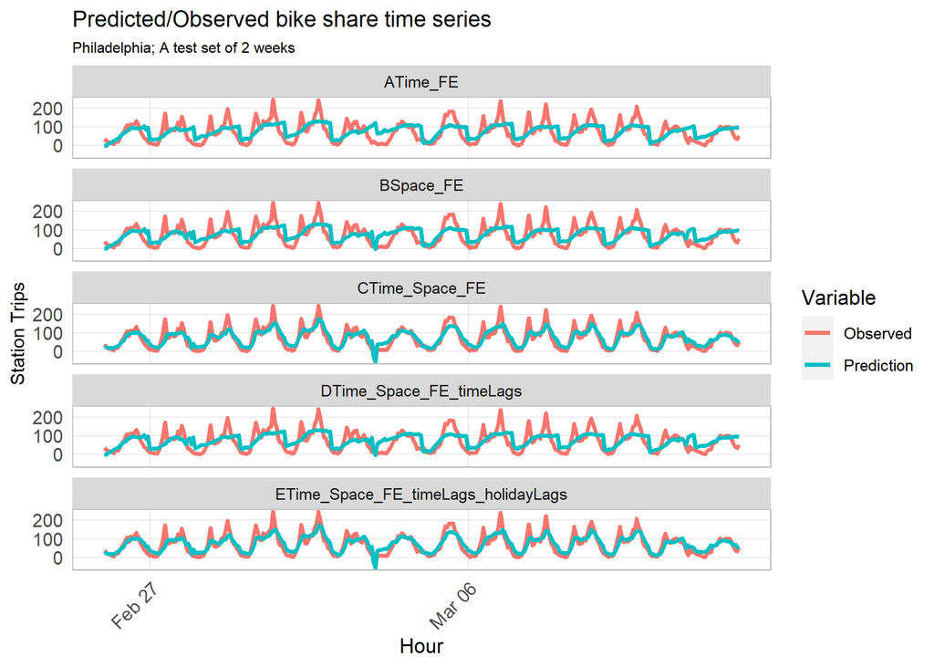

```r
# Predicted vs Observed Values

week_predictions %>%
    mutate(interval60 = map(data, pull, interval60),
           start_station = map(data, pull, start_station)) %>%
    dplyr::select(interval60, start_station, Observed, Prediction, Regression) %>%
    unnest() %>%
    gather(Variable, Value, -Regression, -interval60, -start_station) %>%
    group_by(Regression, Variable, interval60) %>%
    summarize(Value = sum(Value)) %>%
    ggplot(aes(interval60, Value, colour=Variable)) +
      geom_line(size = 1.1) +
      facet_wrap(~Regression, ncol=1) +
      labs(title = "Predicted/Observed bike share time series", subtitle = "Philadelphia; A test set of 2 weeks",  x = "Hour", y= "Station Trips") +
      plotTheme
```

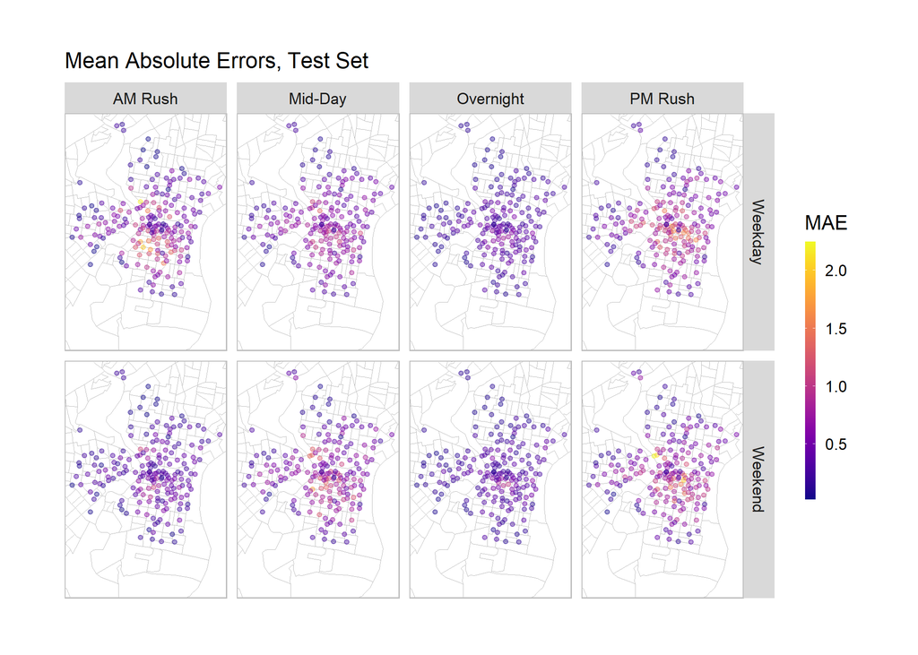

```r
# Errors by Station

week_predictions %>%
    mutate(interval60 = map(data, pull, interval60),
           start_station = map(data, pull, start_station),
           start_lat = map(data, pull, start_lat),
           start_lon = map(data, pull, start_lon),
           dotw = map(data, pull, dotw) ) %>%
    select(interval60, start_station, start_lon,
           start_lat, Observed, Prediction, Regression,
           dotw) %>%
    unnest() %>%
  filter(Regression == "ETime_Space_FE_timeLags_holidayLags")%>%
  mutate(weekend = ifelse(dotw %in% c("Sun", "Sat"), "Weekend", "Weekday"),
         time_of_day = case_when(hour(interval60) < 7 | hour(interval60) > 18 ~ "Overnight",
                                 hour(interval60) >= 7 & hour(interval60) < 10 ~ "AM Rush",
                                 hour(interval60) >= 10 & hour(interval60) < 15 ~ "Mid-Day",
                                 hour(interval60) >= 15 & hour(interval60) <= 18 ~ "PM Rush")) %>%
  group_by(start_station, weekend, time_of_day, start_lon, start_lat) %>%
  summarize(MAE = mean(abs(Observed-Prediction), na.rm = TRUE))%>%
  ggplot(.)+
  geom_sf(data = phillyTracts %>%
          st_transform(crs=4326), color = "grey", fill = "transparent")+
  geom_point(aes(x = start_lon, y = start_lat, color = MAE),
             fill = "transparent", size = 1, alpha = 0.4)+
  scale_colour_viridis(direction = 1,
  discrete = FALSE, option = "C")+
  ylim(min(dat_census$start_lat), max(dat_census$start_lat))+
  xlim(min(dat_census$start_lon), max(dat_census$start_lon))+
  facet_grid(weekend~time_of_day)+
  labs(title="Mean Absolute Errors, Test Set")+
  mapTheme
```

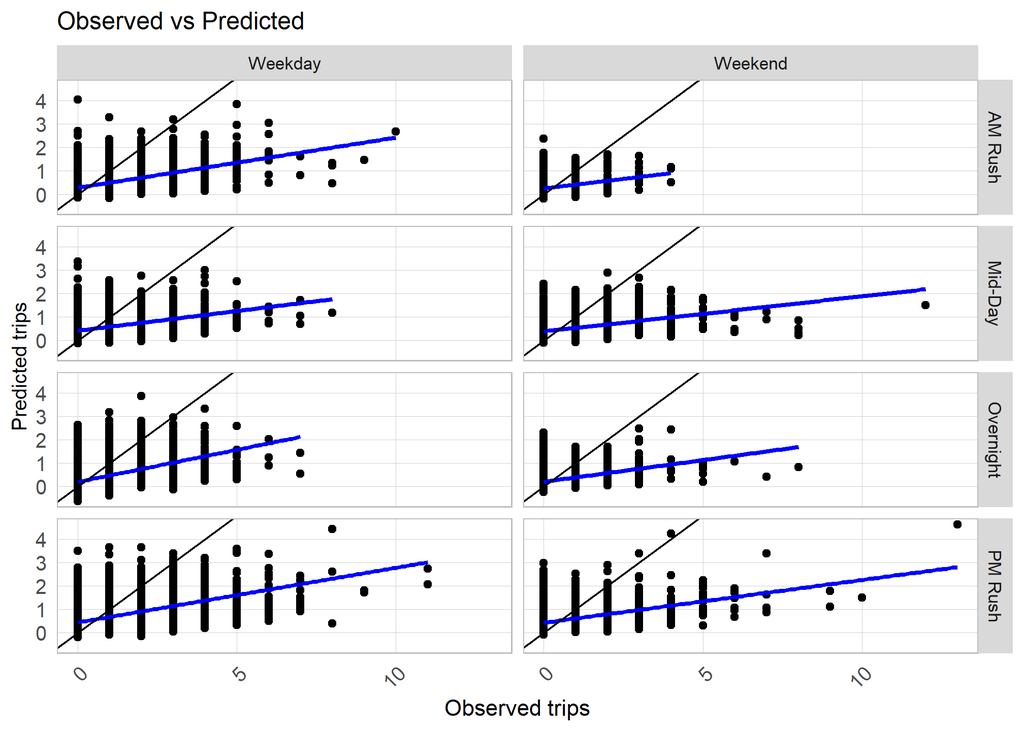

```r
# Predicted vs Observed Scatterplots

week_predictions %>%
    mutate(interval60 = map(data, pull, interval60),
           start_station = map(data, pull, start_station),
           start_lat = map(data, pull, start_lat),
           start_lon = map(data, pull, start_lon),
           dotw = map(data, pull, dotw)) %>%
    select(interval60, start_station, start_lon,
           start_lat, Observed, Prediction, Regression,
           dotw) %>%
    unnest() %>%
  filter(Regression == "ETime_Space_FE_timeLags_holidayLags")%>%
  mutate(weekend = ifelse(dotw %in% c("Sun", "Sat"), "Weekend", "Weekday"),
         time_of_day = case_when(hour(interval60) < 7 | hour(interval60) > 18 ~ "Overnight",
                                 hour(interval60) >= 7 & hour(interval60) < 10 ~ "AM Rush",
                                 hour(interval60) >= 10 & hour(interval60) < 15 ~ "Mid-Day",
                                 hour(interval60) >= 15 & hour(interval60) <= 18 ~ "PM Rush"))%>%
  ggplot()+
  geom_point(aes(x= Observed, y = Prediction))+
    geom_smooth(aes(x= Observed, y= Prediction), method = "lm", se = FALSE, color = "blue")+
    geom_abline(slope = 1, intercept = 0)+
  facet_grid(time_of_day~weekend)+
  labs(title="Observed vs Predicted",
       x="Observed trips",
       y="Predicted trips")+
  plotTheme
```

It is also observed that the model exhibits higher errors in high-income, majority-white neighborhoods which have lower dependence on public transit. This indicates that the model does not generalize well.

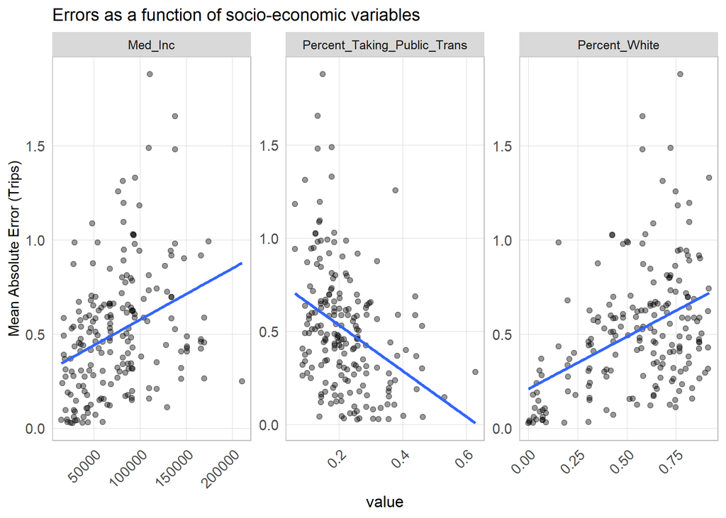

```r
# Generalibility - Socioeconomic factor errors

week_predictions %>%
    mutate(interval60 = map(data, pull, interval60),
           start_station = map(data, pull, start_station),
           start_lat = map(data, pull, start_lat),
           start_lon = map(data, pull, start_lon),
           dotw = map(data, pull, dotw),
           Percent_Taking_Public_Trans = map(data, pull, Percent_Taking_Public_Trans),
           Med_Inc = map(data, pull, Med_Inc),
           Percent_White = map(data, pull, Percent_White)) %>%
    select(interval60, start_station, start_lon,
           start_lat, Observed, Prediction, Regression,
           dotw, Percent_Taking_Public_Trans, Med_Inc, Percent_White) %>%
    unnest() %>%
  filter(Regression == "ETime_Space_FE_timeLags_holidayLags")%>%
  mutate(weekend = ifelse(dotw %in% c("Sun", "Sat"), "Weekend", "Weekday"),
         time_of_day = case_when(hour(interval60) < 7 | hour(interval60) > 18 ~ "Overnight",
                                 hour(interval60) >= 7 & hour(interval60) < 10 ~ "AM Rush",
                                 hour(interval60) >= 10 & hour(interval60) < 15 ~ "Mid-Day",
                                 hour(interval60) >= 15 & hour(interval60) <= 18 ~ "PM Rush")) %>%
  filter(time_of_day == "AM Rush") %>%
  group_by(start_station, Percent_Taking_Public_Trans, Med_Inc, Percent_White) %>%
  summarize(MAE = mean(abs(Observed-Prediction), na.rm = TRUE))%>%
  gather(-start_station, -MAE, key = "variable", value = "value")%>%
  ggplot(.)+
  #geom_sf(data = chicagoCensus, color = "grey", fill = "transparent")+
  geom_point(aes(x = value, y = MAE), alpha = 0.4)+
  geom_smooth(aes(x = value, y = MAE), method = "lm", se= FALSE)+
  facet_wrap(~variable, scales = "free")+
  labs(title="Errors as a function of socio-economic variables",
       y="Mean Absolute Error (Trips)")+
  plotTheme
```

## 5. Conclusion

The predictive model is effective in forecasting rideshare demand, with potential to inform Indego’s rebalancing efforts. It demonstrates a sufficiently high accuracy level, proving its utility, and provides a data-driven approach for responding to emerging demand. However, the model exhibits spatial auto-correlation which manifests in its errors. Furthermore, it does not generalize well and exhibits a trend of underprediction. The model also does not predict reliably for weekends, which may be because of the smaller dataset size considered and therefore fewer observations in this analysis. While the model can be implemented for use for understanding general trends of use, it is not recommended it is used for resource allocation at this stage. In the near-future, the model can be implemented for this scope as well, once it incorporates more nuanced and engineered prediction features to account for spatial effects to improve prediction quality and generalibality.